# コンテナとサーバー

作者

J22069 野倉悠正

公開

2025年11月30日

# 第19回

## 📦コンテナとは

- アプリケーションとその実行に必要なすべての要素（ライブラリ、設定ファイルなど）をコンテナと呼ばれる軽量で独立したパッケージにまとめて隔離できる。
- 実行はその場所のホストOS（PCだったらPCのOS、サーバーだったらサーバーにインストールしたOS）が行う。

### コンテナと仮想マシンの比較

| 特徴 | コンテナ | 仮想マシン（VM） |
| --- | --- | --- |
| OSの包含 | ホストOSのカーネルを共有（ゲストOSなし） | 独自のゲストOSを内包 |
| サイズ・速度 | 軽量、起動が数秒と非常に速い | 重い、OSの起動が必要なため遅い |
| OSの種類 | ホストOSと同じカーネル（LinuxならLinux）しか動かせない | ハイパーバイザ上で異なるOS（例: Windows上でLinux）を動かせる |

### コンテナ化のメリット

- 一度ビルドすればどこでも実行できるので高い移植性と一貫性を持つ
- ゲストOSを必要としないため軽量・高速

### DockerとSingularity(Apptainer)

#### Docker

- デファクトスタンダードとなっているコンテナ化プラットフォーム。
- 開発環境から本番環境まで、幅広い用途で利用されている。
- `Dockerfile` というテキストファイルにコンテナの構成を記述し、それを元にコンテナイメージをビルドする。
- 基本的にコンテナの操作には管理者権限（root）が必要となるため、共有サーバー（HPCなど）での利用にはセキュリティ上の懸念がある。

#### Singularity (Apptainer)

- 主にハイパフォーマンスコンピューティング（HPC）や科学技術計算の分野で利用されることを目的として設計されたコンテナプラットフォーム。
- Singularityは現在Apptainerという名称になっている。
- 一般ユーザー権限でコンテナを実行できるため、複数ユーザーが利用する共有環境でも安全に利用できる。
- コンテナイメージは単一のファイル（SIF: Singularity Image Format）として扱われるため、管理や共有が容易。

#### DockerとSingularity(Apptainer)の比較

| 特徴 | Docker | Singularity (Apptainer) |
| --- | --- | --- |
| 主な用途 | Webアプリケーション、マイクロサービス開発など | HPC、科学技術計算、再現性の高い研究 |
| 実行権限 | 基本的にroot権限が必要 | 一般ユーザー権限で実行可能 |
| イメージ形式 | レイヤー構造 | 単一のファイル（SIF） |
| セキュリティ | root権限での実行がセキュリティリスクになりうる | ユーザー権限で実行するため、より安全 |

### DockerからApptainerへの変換フロー

サーバー（特にHPCのような共有環境）では、セキュリティ上の理由からDockerを直接利用できないことが多い。その場合、ローカル環境で作成したDockerイメージをサーバー上でApptainer（Singularity）形式に変換して利用するのが一般的なワークフローである。

```
graph TD
    subgraph "ローカルPC"
        A[Dockerfile作成] --> B[Dockerイメージ<br>ビルド];
        B --> C[レジストリへ<br>push];
    end

    subgraph "レジストリ"
        D[Dockerイメージ保管];
    end

    subgraph "サーバー (HPCなど)"
        E[イメージから<br>SIFファイルを生成] --> F[SIFファイルで<br>コンテナ実行];
    end
    C --> D --> E;
```

## 🐳Docker環境の構築

- Docker環境を構築するには、Linuxコマンドが必要。
- [Docker Desktop](https://www.docker.com/ja-jp/products/docker-desktop/)を使うと一発で環境構築ができる。

[figure not shown]

  Docker Desktop（macOS版）

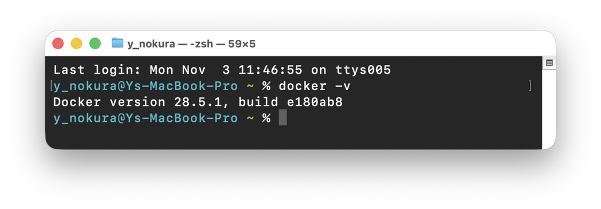

  コマンドラインでのDockerのインストール確認

## 🚀Dockerコンテナを起動してみる

- わかりやすいイメージとしては、Dockerがゲーム機本体、コンテナがゲームのカセット。

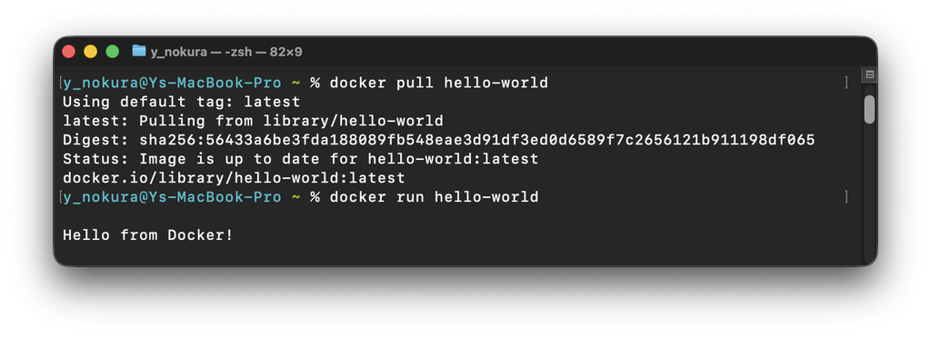

  hello-worldコンテナの実行

## 💻Flask-ReactのWebアプリのコンテナ化

- Docker Composeを使用してフロントエンドとバックエンドを分けて管理
- Nginxなどのリバースプロキシを介して連携

### バックエンド（Flask）側の設定

#### requirements.txtの作成

- 仮想環境してから`pip freeze > requirements.txt`で作成可能。

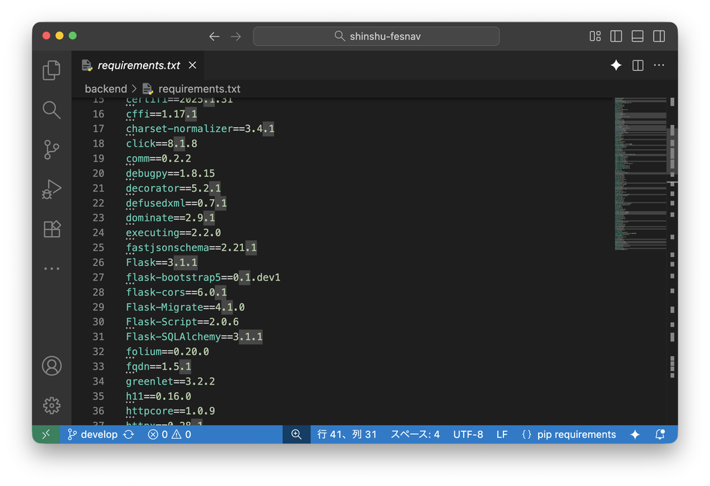

  requirements.txt